# HTML report for Confounding Factors Analysis

Jishu Xu

30 May, 2018

# Purpose

In general, confounding factors in RNA-Seq experiement can be due to the particular experimental protocol, technical artifact,or experiement batch. In this section, we will examine these technical confounding factors from two different pipelines.

# Input data

The key input data for this test are the data matrix generated by two pipelines, they can be gene counts matrix or TPM, FPKM matrix. The detail of input data are listed below

- bdatafile: data matrix from pipeline, such as base pipeline.
- udatafile: data matrix from pipeline, such as updated pipeline.
- bmetrics: QC metrics generated by base pipeline.
- umetrics: QC metrics generated by updated pipeline.
- npcs: number of PCs to extract from PCA analysis
- output_prefix: output prefix or output name.

First load functions we will use in this test

```r
source('analysis_functions.R')
```

Here is the list of input parameters

```r
option_list <- list(
  make_option(
    "--matrix1",
    type = "character",
    default = NULL,
    help = "data matrix file name",
    metavar = "character"
  ),
  make_option(
    "--matrix2",
    type = "character",
    default = NULL,
    help = "updated data matrix file name",
    metavar = "character"
  ),
  make_option(
    "--metrics1",
    type = "character",
    default = NULL,
    help = " base metrics file name",
    metavar = "character"
  ),
  make_option(
    "--metrics2",
    type = "character",
    default = NULL,
    help = " updated metrics file name",
    metavar = "character"
  ),
  make_option(
    "--npcs",
    type = "integer",
    default = 10,
    help = " number of PCs to collect",
    metavar = "number"
  ),
  make_option(
    "--output_prefix",
    type = "character",
    default = "output name",
    help = "output file name [default= %default]",
    metavar = "character"
  ),
  make_option(
    "--metadata_file",
    type = "character",
    default = NULL,
    help = "The metadata file include the information about cell/samples,
    such cell type, cell cycle" ,
    metavar = "character"
  ),
  make_option(
    "--metaKeys",
    type = "character",
    default = NULL,
    help = "the list of meta values to be considered as confounding factors",
    metavar = "character"
  )
)
```

# Parse Inputs

Data matrix files are *.csv file and can be count, TPM or FPKM matrix. For benchmarking purpose, TPM would be optimal choice.

- matrix1: data matrix of one pipeline, such as base pipeline
- matrix2: data matrix of the other pipeline, such as updated pipeline
- metrcs1: QC metrics of one pipeline.
- metric2: QC metrics of the other pipeline
- metadata_file: a file includes metadata information about data, such cell, lineage.
- metaKeys: a list of meta value to extract, such cell, lineage.
- npcs: top number of PCs to extract in PCA

```r
# load matrix file
# args rendered by rmkdown
args <- strsplit(commandArgs(trailingOnly = TRUE), split = ' ')
opt_parser <- OptionParser(option_list = option_list)
opt <- parse_args(opt_parser, args = args[[1]])
met1 <- read.csv(opt$metrics1,row.names=1)
met2 <- read.csv(opt$metrics2,row.names=1)
mat1 <- read.csv(opt$matrix1)
mat2 <- read.csv(opt$matrix2)
npcs <- opt$npcs
output_name <- opt$output_prefix
```

metadata records information related to this dataset, such as ‘cell lineage’,‘celltype’,‘is population’

```r
# parse metadata
metaKeys <- strsplit(opt$metaKeys, split = ',')[[1]]
knitr::kable(metaKeys)
```

| x |
| --- |
| cell |
| lineage |

```r
meta <- read.delim(opt$metadata_file, sep = ',', header = T)
knitr::kable(head(meta))
```

| sra | cell | lineage | origin | population |
| --- | --- | --- | --- | --- |
| SRR5676728 | neuron | Day 100 | human cortical spheroid-derived cell | sc |
| SRR5676729 | glia | Day 100 | human cortical spheroid-derived cell | sc |
| SRR5676730 | glia | Day 100 | human cortical spheroid-derived cell | sc |
| SRR5676731 | neuron | Day 100 | human cortical spheroid-derived cell | sc |
| SRR5676732 | glia | Day 100 | human cortical spheroid-derived cell | sc |
| SRR5676733 | neuron | Day 100 | human cortical spheroid-derived cell | sc |

add rowname and remove index columns

```r
rownames(mat1) <- mat1[, 1]
rownames(mat2) <- mat2[, 1]
mat1.d <- mat1[, -c(1:2)]
mat2.d <- mat2[, -c(1:2)]
```

## Data Processing

First, we match data matrix by both column and row names

```r
mlist <- match(rownames(mat1.d), rownames(mat2.d))
nlist <- match(colnames(mat1.d), colnames(mat2.d))
mat2.d <- mat2.d[mlist, nlist]
```

Then we will match data matrix with QC.

```r
met1.h <- colnames(met1)
met2.h <- colnames(met2)
mlist1 <- match(colnames(mat1.d), met1.h)
mlist2 <- match(colnames(mat2.d), met2.h)
met1 <- met1[, mlist1]
met2 <- met2[, mlist2]
```

We will match the matrix with meta data as well

```r
mlist <- match(colnames(mat1.d), meta$sra)
meta <- meta[mlist, ]
```

## Data Matrix Transformation

First, take log2 transformation.

```r
# log2 transformation
mat1.log2 <- takelog2(mat1.d)
mat2.log2 <- takelog2(mat2.d)
```

# Confounding Factors

## Technical Confounding factors

We propose the following way extract top technical confounding factors informatin. First we run PCA on QC metrics and then extract the top 10PCs These top 10-PCs should represent the majority variance in QC metrics.

```r
met1.pcas <- RunPCAMetrix(met1)
met2.pcas <- RunPCAMetrix(met2)
```

### Base Pipeline Metrics PCA

Then let’s check out the PCA results. The ‘scree plot’ show the `%` of variance explained by PCs

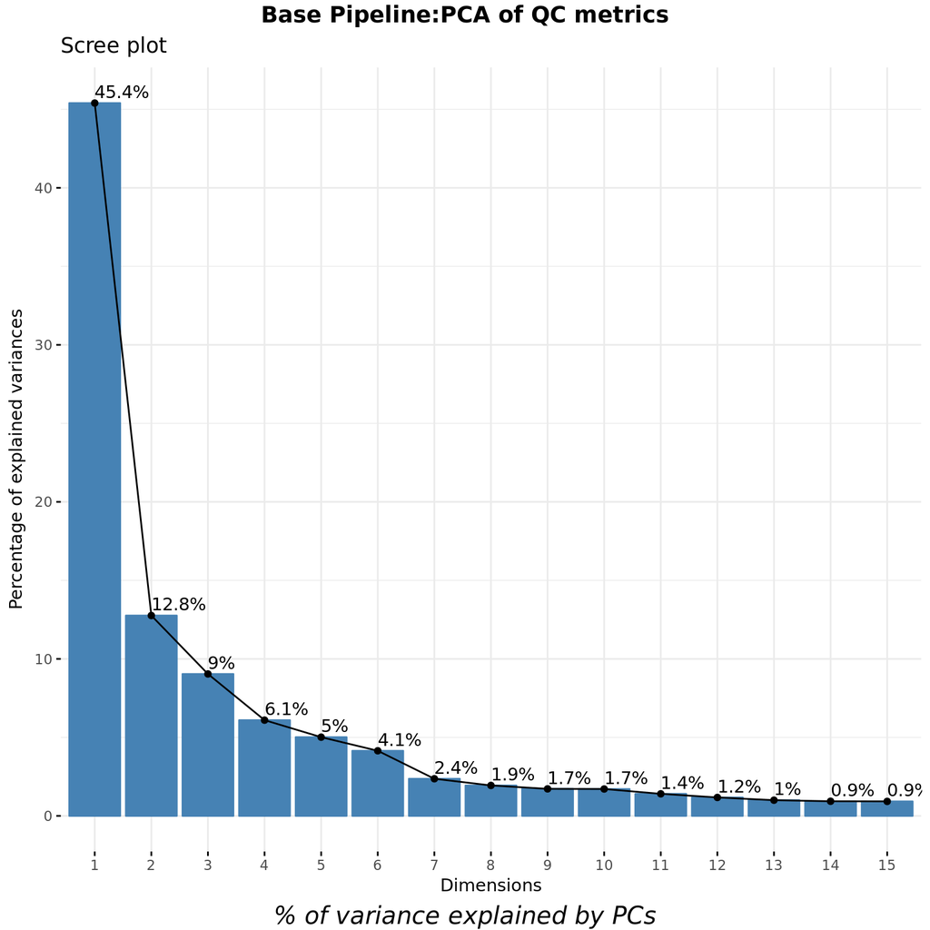

```r
fp <- fviz_screeplot(met1.pcas$PCs, ncp = 15, addlabels = TRUE)
annotate_figure(
  fp,
  top = text_grob(
    "Base Pipeline:PCA of QC metrics",
    face = "bold",
    size = 14
  ),
  bottom = text_grob(
    "% of variance explained by PCs",
    face = "italic",
    size = 15
  )
)
```

### Update Pipeline Metrics PCA

Then let’s check out the PCA results. The ‘scree plot’ show the `%` of variance explained by PCs

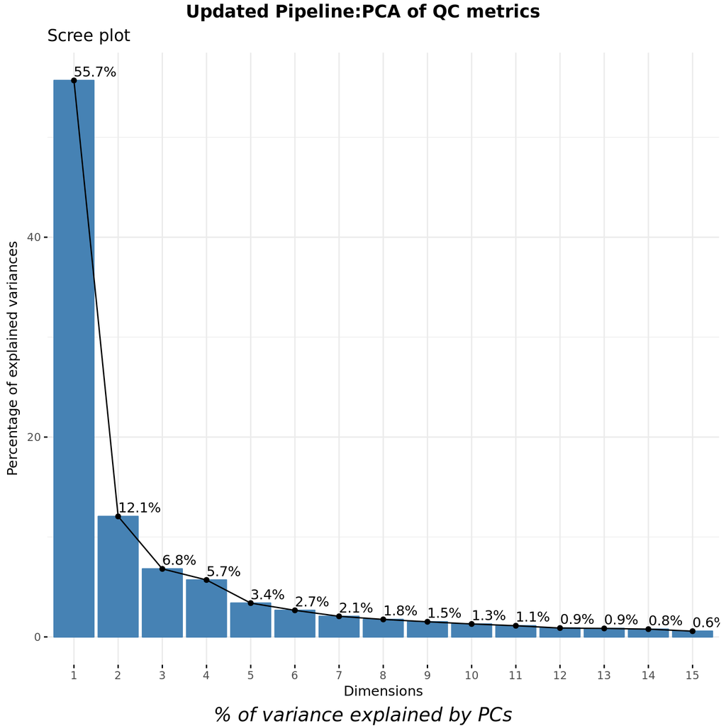

```r
fp <- fviz_screeplot(met2.pcas$PCs, ncp = 15, addlabels = TRUE)
annotate_figure(
  fp,
  top = text_grob(
    "Updated Pipeline:PCA of QC metrics",
    face = "bold",
    size = 14
  ),
  bottom = text_grob(
    "% of variance explained by PCs",
    face = "italic",
    size = 15
  )
)
```

Then we extract the top 10 PCs to represent the QC metrics for both pipelines.

```r
met1.pcs <- met1.pcas$PCs$rotation[, 1:10]
colnames(met1.pcs) <- paste('QC.', 'PC', 1:10, sep = '')
met2.pcs <- met2.pcas$PCs$rotation[, 1:10]
colnames(met2.pcs) <- paste('QC.', 'PC', 1:10, sep = '')
```

## Biological Confounding factors

Cell type can explain significant amount of gene expression variance as well as cell cycle. If cell cycle is not the main purpose of the experiement, it can be treated as biological confounding factor. We combine technical and biological confounding factors tegether.

```r
# Confounding factors
df1 <- data.frame(met1.pcs, meta[, metaKeys])
df2 <- data.frame(met2.pcs, meta[, metaKeys])
```

## Data Matrix PCA analysis

We will examine each technical confounding factors effect by examining the percentage of variance they can explain for total expression data. For the efficiency, we will use the top `npcs` PCs to represent gene expression data. We first run a PCA analysis by using prcomp() function then use CumulateVar() function to calcuate the cumulated variance of PCA.

```r
# base pipeline
mat1.pca <- prcomp(mat1.d, scale = F)
mat1.var <- CumulateVar(mat1.pca)
mat1.sub <- t(mat1.pca$rotation[, c(1:npcs)])
rownames(mat1.sub) <- paste('exp.', 'PC', 1:npcs, sep = '')
```

visualize data matrix PCA results by scree plot

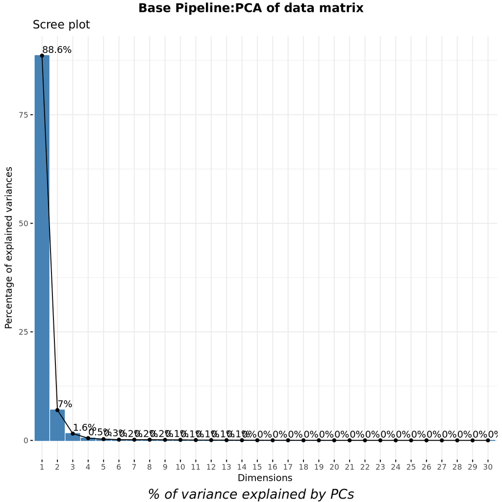

```r
fp <- fviz_screeplot(mat1.pca, ncp = 30, addlabels = TRUE)
annotate_figure(
  fp,
  top = text_grob(
    "Base Pipeline:PCA of data matrix",
    face = "bold",
    size = 14
  ),
  bottom = text_grob(
    "% of variance explained by PCs",
    face = "italic",
    size = 15
  )
)
```

```r
# updated pipeline
mat2.pca <- prcomp(mat2.d, scale = F)
mat2.var <- CumulateVar(mat2.pca)
mat2.sub <- t(mat2.pca$rotation[, c(1:npcs)])
rownames(mat2.sub) <- paste('exp.', 'PC', 1:npcs, sep = '')
```

visualize data matrix PCA results by scree plot

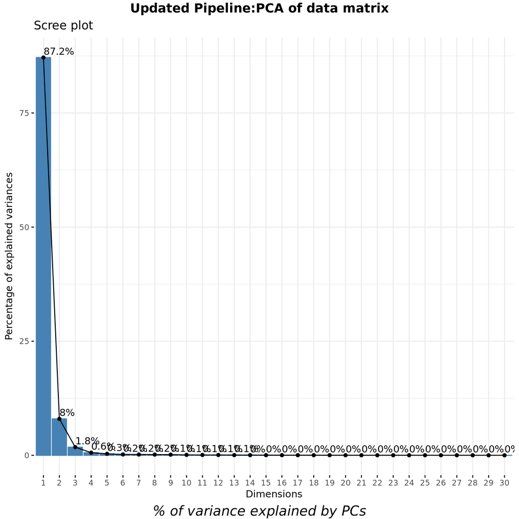

```r
fp <- fviz_screeplot(mat2.pca, ncp = 30, addlabels = TRUE)
annotate_figure(
  fp,
  top = text_grob(
    "Updated Pipeline:PCA of data matrix",
    face = "bold",
    size = 14
  ),
  bottom = text_grob(
    "% of variance explained by PCs",
    face = "italic",
    size = 15
  )
)
```

# Variance Analysis

We will build up a linear model such as
$$Exp.PCs = QC.PCs+cell+lineage+residual$$
The we will apply ANOVA test on this linear model to extract `%` of variance explained by each predictors.

## Base Pipeline Variance Analysis

Run variance analysis

```r
vars1 <-
  apply(mat1.sub, 1, function(x) {
    RunVarianceAnalysis(x, df1)
  })
```

Extract proportion of variance.

```r
knitr::kable(head(vars1))
```

|  | exp.PC1 | exp.PC2 | exp.PC3 | exp.PC4 | exp.PC5 | exp.PC6 | exp.PC7 | exp.PC8 | exp.PC9 | exp.PC10 |
| --- | --- | --- | --- | --- | --- | --- | --- | --- | --- | --- |
| QC.PC1 | 0.0323559 | 0.5894310 | 0.1952672 | 0.0403928 | 0.0002121 | 0.0019300 | 0.0044644 | 0.0028231 | 0.0032069 | 0.0012687 |
| QC.PC2 | 0.5327123 | 0.1663296 | 0.2033400 | 0.0315133 | 0.0003793 | 0.0029974 | 0.0186378 | 0.0046329 | 0.0038215 | 0.0022546 |
| QC.PC3 | 0.2703383 | 0.1116877 | 0.1283772 | 0.0004682 | 0.0209828 | 0.0004603 | 0.0009425 | 0.0001305 | 0.0000345 | 0.0000010 |
| QC.PC4 | 0.0417163 | 0.0000922 | 0.0252010 | 0.0514242 | 0.0196181 | 0.0023313 | 0.0588571 | 0.1290895 | 0.0004903 | 0.0043179 |
| QC.PC5 | 0.0178711 | 0.0025884 | 0.1379210 | 0.0057818 | 0.0132238 | 0.0018345 | 0.0147020 | 0.0389695 | 0.0071894 | 0.0023434 |
| QC.PC6 | 0.0243466 | 0.0001310 | 0.0462480 | 0.0048103 | 0.0026593 | 0.0061511 | 0.1125513 | 0.0475640 | 0.0948402 | 0.0021814 |

## Updated Pipeline Variance Analysis

Run variance analysis

```r
vars2 <-
  apply(mat2.sub, 1, function(x) {
    RunVarianceAnalysis(x, df2)
  })
```

Extract proportion of variance.

```r
knitr::kable(head(vars2))
```

|  | exp.PC1 | exp.PC2 | exp.PC3 | exp.PC4 | exp.PC5 | exp.PC6 | exp.PC7 | exp.PC8 | exp.PC9 | exp.PC10 |
| --- | --- | --- | --- | --- | --- | --- | --- | --- | --- | --- |
| QC.PC1 | 0.0988621 | 0.8348104 | 0.0029945 | 0.0080419 | 0.0000076 | 0.0081254 | 0.0005497 | 0.0037737 | 0.0015514 | 0.0111650 |
| QC.PC2 | 0.7316903 | 0.0001687 | 0.6033410 | 0.0492050 | 0.0001185 | 0.0115917 | 0.0057935 | 0.0053127 | 0.0126041 | 0.0166384 |
| QC.PC3 | 0.0054502 | 0.0243796 | 0.0282316 | 0.0238091 | 0.0097228 | 0.0245064 | 0.0009923 | 0.0207450 | 0.0261963 | 0.0813348 |
| QC.PC4 | 0.0002047 | 0.0000982 | 0.0209626 | 0.0031237 | 0.0002330 | 0.0073061 | 0.2767089 | 0.0000736 | 0.0125931 | 0.0527928 |
| QC.PC5 | 0.0795284 | 0.0036108 | 0.0922961 | 0.0332654 | 0.0057101 | 0.1411974 | 0.0024706 | 0.0086913 | 0.0010333 | 0.0021719 |
| QC.PC6 | 0.0190731 | 0.0006303 | 0.0352007 | 0.0085755 | 0.0084464 | 0.0100360 | 0.0045167 | 0.0082892 | 0.0028538 | 0.0008951 |

## Visualize Variance Analysis

We can visualize these variance explained by confounding factors in boxplot/violin plots.

```r
mvar1 <- melt(vars1)
mvar2 <- melt(vars2)
```

Plot in boxplot of Base pipeline analysis results.

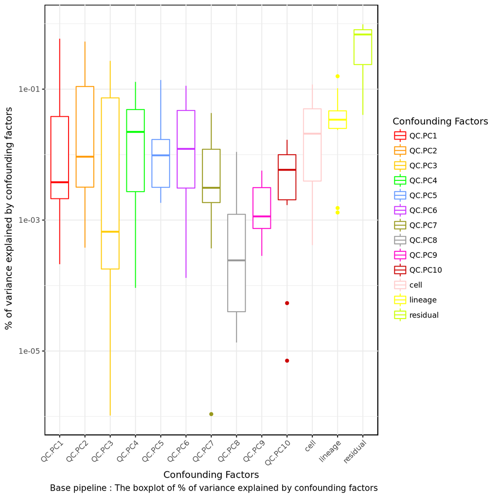

```r
ggboxplot(
  mvar1,
  x = "Var1",
  y = "value",
  color = "Var1",
  palette = 'ucscgb',
  legend.title = "Confounding Factors",
  caption = "Base pipeline : The boxplot of % of variance explained by confounding factors",
  ggtheme = theme_minimal(),
  x.text.angle = 45
) + scale_y_log10() +
  xlab('Confounding Factors') +
  ylab(' % of variance explained by confounding factors') +
  border()
```

Plot in boxplot of updated pipeline analysis results.

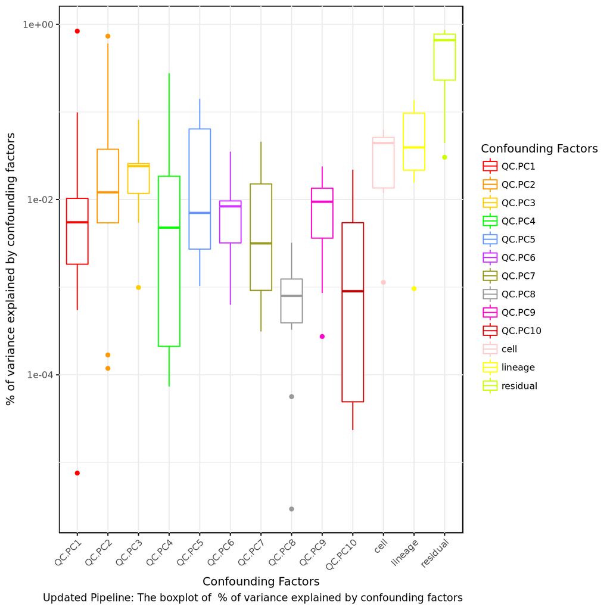

```r
 ggboxplot(
  mvar2,
  x = "Var1",
  y = "value",
  color = "Var1",
  ggtheme = theme_minimal(),
  legend.title = "Confounding Factors",
  caption = "Updated Pipeline: The boxplot of  % of variance explained by confounding factors",
  palette = 'ucscgb',
  x.text.angle = 45
) + scale_y_log10() +
  xlab('Confounding Factors') +
  ylab('% of variance explained by confounding factors') +
  border()
```

# Compare the confounding factors of two pipelines

Here, we split the variants of gene expression into 3 categories, * explained by technical confounding factors * explained by biological factors, such cell type or cell cycle. * explained by others or unknown.

First we calculate the overall mean of `%` of varaince explained by each confounding factors

```r
# factors name
vn <- c(rep('technical', ncol(met1.pcs)),
        rep('biological', length(metaKeys)),
        'others')
```

`findProportion()` function will return a vector in which include `%` of variance explained by technical, biological and others confounding factors.

```r
vp1 <- findProportion(vars1, vn)
vp2 <- findProportion(vars2, vn)
p <- merge(vp1,
           vp2,
           by = c('Group.1'),
           suffixes = c('.Base', '.Updated'))
knitr::kable(p)
```

| Group.1 | x.Base | x.Updated |
| --- | --- | --- |
| biological | 0.0807939 | 0.0921630 |
| others | 0.5688853 | 0.5324329 |
| technical | 0.3503209 | 0.3754041 |

### Base Pipeline: Variance Analysis Results

We can plot pie chart to visualize the `%` of variance explained by confounding factors.

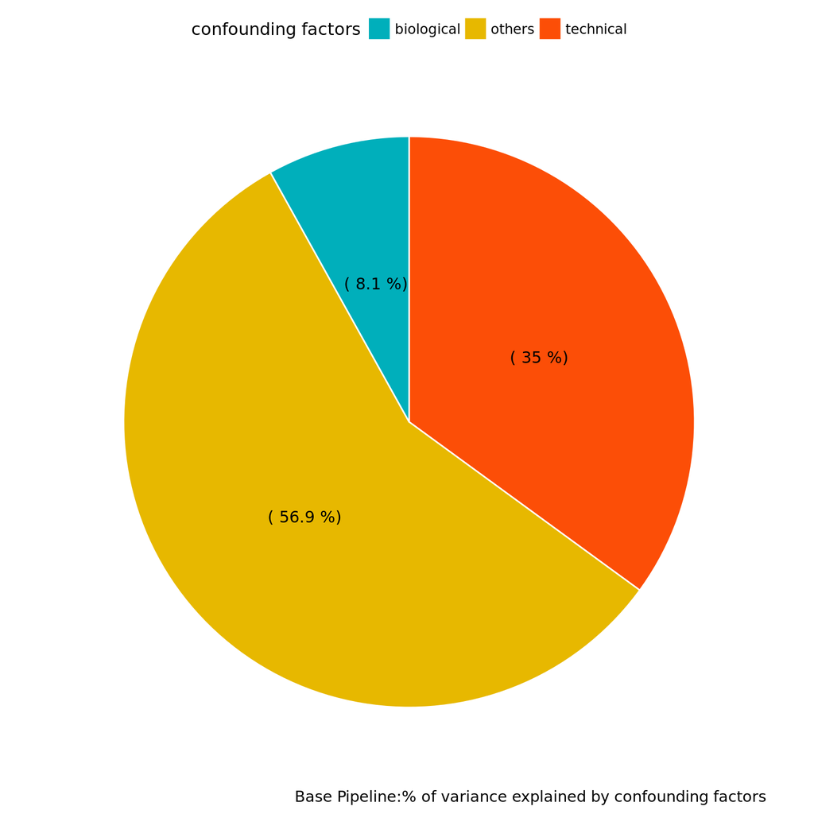

```r
labs <- paste(" (", round(p$x.Base * 100, 1), "%)")
p['x.labels'] <- labs
ggpie(
  p,
  "x.Base",
  label = 'x.labels',
  fill = "Group.1",
  color = "white",
  lab.pos = "in",
  lab.font = "bold.italic",
  palette = c("#00AFBB", "#E7B800", "#FC4E07"),
  ggtheme = theme_pubr(),
  caption = "Base Pipeline:% of variance explained by confounding factors",
  legend.title = "confounding factors"
)
```

### Updated Pipeline: Variance Analysis Results

We can plot pie chart to visualize the `%` of variance explained by confounding factors.

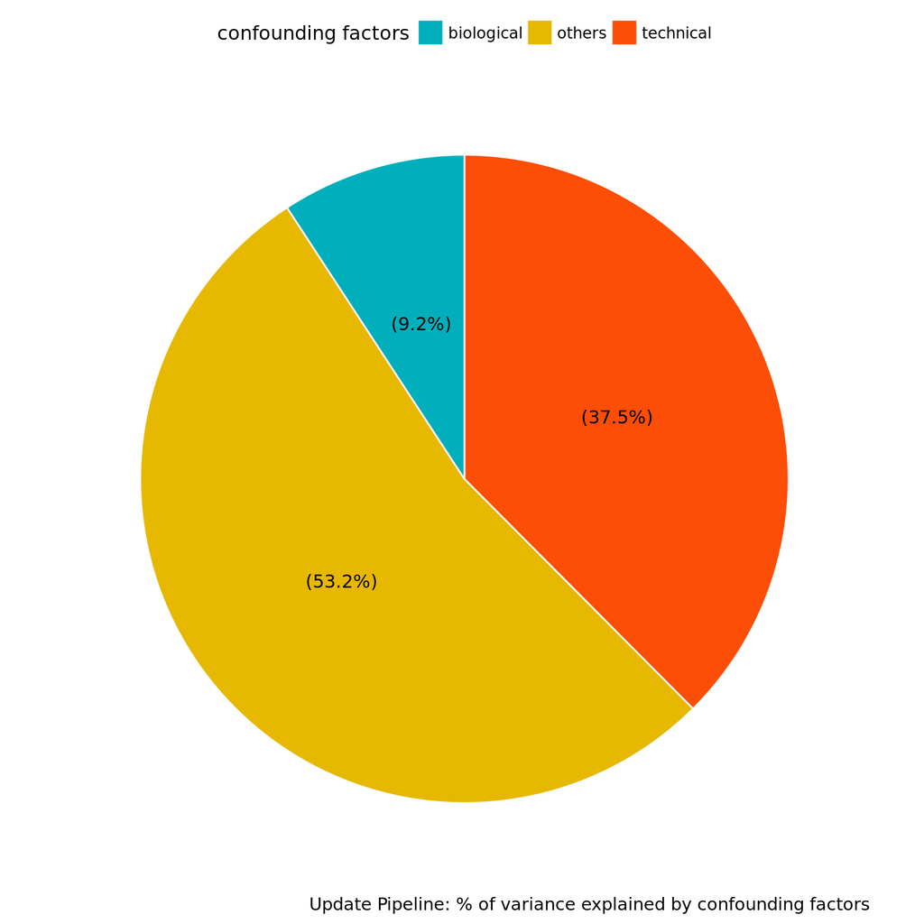

```r
labs <- paste0(" (", round(p$x.Updated * 100, 1), "%)")
p['y.labels'] <- labs
ggpie(
  p,
  "x.Updated",
  label = 'y.labels',
  fill = "Group.1",
  color = "white",
  lab.pos = "in",
  lab.font = "bold.italic",
  palette = c("#00AFBB", "#E7B800", "#FC4E07"),
  ggtheme = theme_pubr(),
  caption = "Update Pipeline: % of variance explained by confounding factors",
  legend.title = "confounding factors"
)
```

# Output

At the end, we will output the variance proportion represented by confounding factors into a file.

```r
write.csv(p,
          file = paste(
            output_name,
            '_confounding_factors_vars.csv',
            sep=''),
            quote = F,
            row.names = F
          )
```